# Stats Test 1

Question 1: Load relevant packages:

```r
library(pacman)
p_load(tidyverse, haven, magrittr, readxl, labelled, psych, janitor, class, caret, vcd, e1071, readr, stringr, knitr, kableExtra, broom, boot, gmodels, glmnet, MASS, leaps, Metrics, ISLR, randomForest, tree, gbm, car, merTools)
```

Load relevant data Convert conviction data from long to wide Combine conviction data with delinquency data

```r
delinquent <- read_spss("../statstest_1/data/Cambridge_delinquency.sav")
conviction <- read_spss("../statstest_1/data/conviction_data.sav")
wide_conviction <- spread(data = conviction, key = agecat, value = convicted)
icpsr_seq_id_number <- 1:411
delinquent$icpsr_seq_id_number <- icpsr_seq_id_number
join_delinquent <- full_join(delinquent, wide_conviction, by = "icpsr_seq_id_number")
```

Create new data frame with potential outcome variables: Select pariticipant ID number, “Number of juvenile convictions”, “Number of adult convictions”, and “Number of overall convictions” to begin the new data Rename ID number (PID), number of juvenile convictions (njuv_convict), number of adult convictions (nadult_convict), and number of overall convictions (nconvict). Recode variables so that they’re on comparable scales: 0 = no convictions 1 = 1 conviction 2 = 2 or 3 convictions 3 = 4 or more convictions Check that recoding is correct

Check correlation of potential outcome variables with pairs panel, using Spearman’s rho (rs) for ordinal data.

```r
criminality1 <- dplyr::select(join_delinquent, PID = icpsr_seq_id_number, njuv_convict = v28, nadult_convict = v29, nconvict = v30)
criminality2 <- dplyr::select(criminality1, PID, njuv_convict, nadult_convict, nconvict)
criminality2$njuv_convict <- recode(criminality2$njuv_convict, "1=0; 2=1; 3=2; 4=3")
criminality2$nadult_convict <- recode(criminality2$nadult_convict, "1=0; 2=1; 3=2; 4=3")
criminality2$nconvict <- recode(criminality2$nconvict, "1=0; 2=1; 3:4=2; 5:6=3")
describe(criminality1)
```

|  | vars | n | mean | sd | median | trimmed | mad | min | max | range | skew | kurtosis | se |
| --- | --- | --- | --- | --- | --- | --- | --- | --- | --- | --- | --- | --- | --- |
| PID | 1 | 411 | 206.00 | 118.79 | 206 | 206.00 | 152.71 | 1 | 411 | 410 | 0.00 | -1.21 | 5.86 |
| njuv_convict | 2 | 411 | 1.33 | 0.74 | 1 | 1.13 | 0.00 | 1 | 4 | 3 | 2.33 | 4.64 | 0.04 |
| nadult_convict | 3 | 395 | 1.50 | 0.92 | 1 | 1.28 | 0.00 | 1 | 4 | 3 | 1.70 | 1.57 | 0.05 |
| nconvict | 4 | 397 | 1.86 | 1.51 | 1 | 1.51 | 0.00 | 1 | 6 | 5 | 1.68 | 1.48 | 0.08 |

```r
describe(criminality2)
```

|  | vars | n | mean | sd | median | trimmed | mad | min | max | range | skew | kurtosis | se |
| --- | --- | --- | --- | --- | --- | --- | --- | --- | --- | --- | --- | --- | --- |
| PID | 1 | 411 | 206.00 | 118.79 | 206 | 206.00 | 152.71 | 1 | 411 | 410 | 0.00 | -1.21 | 5.86 |
| njuv_convict | 2 | 411 | 0.33 | 0.74 | 0 | 0.13 | 0.00 | 0 | 3 | 3 | 2.33 | 4.64 | 0.04 |
| nadult_convict | 3 | 395 | 0.50 | 0.92 | 0 | 0.28 | 0.00 | 0 | 3 | 3 | 1.70 | 1.57 | 0.05 |
| nconvict | 4 | 397 | 0.65 | 1.04 | 0 | 0.44 | 0.00 | 0 | 3 | 3 | 1.31 | 0.21 | 0.05 |

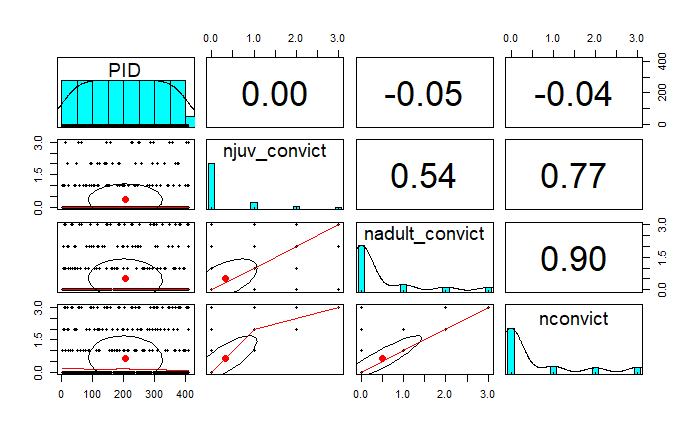

```r
pairs.panels(criminality2, method = "spearman")
```

We see that the mean, median, minimum, and maximum values of juvenile and adult conviction decrease by eaxtly one unit from criminality1 to criminality2, the standard deviations, number of participants, and range remain constant, as do estimates of skew, kurtosis, and standard error - This confirms that the recode was executed according to plan. Changes occur in the third variable (number of overall convictions) between data sets, because some of the levels were collapsed (to mirror the levels in the first two variables).

From the correlation matrix we see that there is only a moderate correlation between number of juvenile and adult convictions (rs = .54) indicating that not all convicted juveniles go on to adult conviction, and not all adult convicts were initially juvenile convicts. Number of juvenile convictions predict number of overall convictions less strongly than number of adult convictions does (rs = .77 and rs = .90 respectively), indicating that the biggest influence on overall conviction is conviction in adulthood. Thus we conclude that not all juvenile convicts continue with criminality into adulthood (at least to the same degree), and the subsample that have a higher number of convictions in adulthood are slightly more representative of those who have higher level of convictions overall (criminality overall spikes in adulthood). Thus is is useful to consider 2 models - 1) predictors that lead to juvenile criminality (and which go on to predict adult criminality to a moderate degree), and 2) predictors that lead to criminality in adulthood (which predicts overall criminality to a high degree). —————————–

Next, we consider predictor variables for our primary outcomes (juvenile and adult criminality) I am interested in what parent-child relationship variables predict criminality in the boys. There is extensive literature on the realtionship between child/adult outcomes and relational factors such as attachment style, early separations, and discipline. It is of interest which (if any) parent-child relational variables predict criminality as a juvenile, and as an adult, respectively. For the purposes of this model I will only consider primary relational processes (e.g.: separations, discipline), and not secondary relational processes (e.g.: unhappiness of father/mother, which may spill over into their relationship with their son). Furthermore, I will only consider dichotemous, ordinal or continuous variables (or those that can be recoded as such)

The following factors are selected for consideration:

Ages 8-9: Discipline of father or mother (v59, v60), discipline quality of father & mother (v 62 & v63), Interest in children by father (v90), maternal and paternal attitude (v99 & v 118), physical neglect of boy (v123), praise by parents (v124), rules of parents (v132), broken home before age 10 (v134), separations up to 5 from father or mother or parents (v139, v140 & v141), separations before 10 from father or mother or parents (v144, v 145 & v 146) , temporary separations up to age 5 from father or mother or parents (v148, v149, v150), temporary separations up to age 10 from father or mother or parents (v151, v152 & v 153), vigilance of parents (v159) Ages 10-11: Attitude of father combined or mother combined (v178 & v179), authoritarianism of parents combined (v180), maternal and paternal attitude (v227 & v248), P. A. S. father and mother authoritarian (v249 & v250), P. A. S. mother underconcerned (v251), supervision by parents (v274) Ages 12-13: Parental approval of boy (v416), broken home before 15 (v425) Ages 16-17: Who boy is living with (v495) Ages 18-19: Natural parents alive or dead (v626), Living circumstances (parent/foster or other; v627), living preferences (v628), agreement with mother and father (v629 & v630), relationships with parents combined (v791) Ages 21-22: Age left home (v814) All new variable names end with a record of the boys age at the time of that round of data collection. Thus “8y” indicates that the data was collected dueing the “ages 8-9” round. Some variables (e.g.: supervision_parents_score) was reported during a different round (e.g.: “ages 10 - 11”), but is actually an amalgamation of scores collected during an earlier round (e.g.: “ages 8 - 9”). In these cases they are labelled to indicate the time of raw score collection (e.g.“8y”), not the time that it was amalgamated and reported (e.g.: “10y”), as no new information was collected (it is just data wrangling by the researchers) . Only the variables collected before age 17 can be used as predictors of juvenile delinquency, and all variables can be used as predcitors of adult delinquency

Next, we need to recode the variables so that they are amenable to analysis (see attached codebook for detailed recoding)

```r
predictor_variables.dat <- dplyr::select(join_delinquent,
                                         PID = icpsr_seq_id_number,
                              discipline_father_8y = v59, discipline_mother_8y = v60, discipline_quality_father_8y = v62, discipline_quality_mother_8y = v63,           father_interest_8y = v90, maternal_attitude_8y = v99, paternal_attitude_8y = v118,              neglected_8y = v123, parent_praise_8y = v124, parent_rules_8y = v132, permanent_sep_parent_8y = v134, over1mo_sep_father_under5y = v139, over1mo_sep_mother_under5y = v140, over1mo_sep_parent_under5y = v141, over1mo_sep_father_under10y = v144, over1mo_sep_mother_under10y = v145, over1mo_sep_parent_under10y = v146, temp_sep_father_under5y = v148, temp_sep_mother_under5y = v149, temp_sep_parent_under5y = v150, temp_sep_father_under10y = v151, temp_sep_mother_under10y = v152, temp_sep_parent_under10y = v153, parent_vigilance_8y = v159,
                             attitude_father_score_8y = v178, attitude_mother_score_8y = v179, pas_authoritarianism_parents_10y = v180, maternal_attitude_10y = v227, paternal_attitude_10y = v248, pas_authoritarianism_father_10y = v249, pas_authoritarianism_mother_10y = v250,pas_underconcerned_mother_10y = v251, supervision_parents_score_8y = v274,
                             parent_approval_12y = v416, permanent_sep_parent_12y = v425,
                             live_parents_home_16y = v495,
                             parents_alive_18y = v626, live_parentsorfoster_home_16y = v627, want_live_parents_home_18y = v628, agreement_mother_18y = v629, agreement_father_18y = v630, harmony_parents_score_18y = v791,
                             age_left_home_21y = v814)
predictor_variables_recode.dat <- predictor_variables.dat
predictor_variables_recode.dat$discipline_father_8y <-     recode(predictor_variables_recode.dat$discipline_father_8y, "2=3; 3=2; 4=2; 5=3")
predictor_variables_recode.dat$discipline_mother_8y <- recode(predictor_variables_recode.dat$discipline_mother_8y, "2=3; 3=2; 4=2; 5=3")
predictor_variables_recode.dat$discipline_quality_father_8y <- recode(predictor_variables_recode.dat$discipline_quality_father_8y, "4=2")
predictor_variables_recode.dat$discipline_quality_mother_8y <- recode(predictor_variables_recode.dat$discipline_quality_mother_8y, "4=2")
predictor_variables_recode.dat$father_interest_8y <- recode(predictor_variables_recode.dat$father_interest_8y, "3=NA")
predictor_variables_recode.dat$maternal_attitude_8y <- recode(predictor_variables_recode.dat$maternal_attitude_8y, "3=2; 4:6=3")
predictor_variables_recode.dat$paternal_attitude_8y <- recode(predictor_variables_recode.dat$paternal_attitude_8y, "4=2")
predictor_variables_recode.dat$permanent_sep_parent_8y <- recode(predictor_variables_recode.dat$permanent_sep_parent_8y, "3=2")
predictor_variables_recode.dat$over1mo_sep_father_under5y <- recode(predictor_variables_recode.dat$over1mo_sep_father_under5y, "3=2")
predictor_variables_recode.dat$over1mo_sep_mother_under5y <- recode(predictor_variables_recode.dat$over1mo_sep_mother_under5y, "3=2")
predictor_variables_recode.dat$over1mo_sep_parent_under5y <- recode(predictor_variables_recode.dat$over1mo_sep_parent_under5y, "3=2")
predictor_variables_recode.dat$over1mo_sep_father_under10y <- recode(predictor_variables_recode.dat$over1mo_sep_father_under10y, "3=2")
predictor_variables_recode.dat$over1mo_sep_mother_under10y <- recode(predictor_variables_recode.dat$over1mo_sep_mother_under10y, "3=2")
predictor_variables_recode.dat$over1mo_sep_parent_under10y <- recode(predictor_variables_recode.dat$over1mo_sep_parent_under10y, "3=2")
predictor_variables_recode.dat$temp_sep_father_under5y <- recode(predictor_variables_recode.dat$temp_sep_father_under5y, "3=2")
predictor_variables_recode.dat$temp_sep_mother_under5y <- recode(predictor_variables_recode.dat$temp_sep_mother_under5y, "3=2")
predictor_variables_recode.dat$temp_sep_parent_under5y <-recode(predictor_variables_recode.dat$temp_sep_parent_under5y, "3=2")
predictor_variables_recode.dat$temp_sep_father_under10y <- recode(predictor_variables_recode.dat$temp_sep_father_under10y, "3=2")
predictor_variables_recode.dat$temp_sep_mother_under10y <- recode(predictor_variables_recode.dat$temp_sep_mother_under10y, "3=2")
predictor_variables_recode.dat$temp_sep_parent_under10y <- recode(predictor_variables_recode.dat$temp_sep_parent_under10y, "3=2")
predictor_variables_recode.dat$maternal_attitude_10y <- recode(predictor_variables_recode.dat$maternal_attitude_10y, "3=2; 4:5=3")
predictor_variables_recode.dat$paternal_attitude_10y <- recode(predictor_variables_recode.dat$paternal_attitude_10y, "4=2")
predictor_variables_recode.dat$permanent_sep_parent_12y <- recode(predictor_variables_recode.dat$permanent_sep_parent_12y, "3=2")
predictor_variables_recode.dat$live_parents_home_16y <- recode(predictor_variables_recode.dat$live_parents_home_16y, "3=2")
predictor_variables_recode.dat$parents_alive_18y <- recode(predictor_variables_recode.dat$parents_alive_18y, "3=2; 4=3")
predictor_variables_recode.dat$live_parentsorfoster_home_16y <- recode(predictor_variables_recode.dat$live_parentsorfoster_home_16y, "2:3=1; 4:6=2")
predictor_variables_recode.dat$age_left_home_21y <- recode(predictor_variables_recode.dat$age_left_home_21y, "000=NA; 106=1; 109=2; 808=3; 999=4")
predictor_variables_recode.dat <- apply(predictor_variables_recode.dat, 2, function(x) {x[x == 0] <- NA; x})
predictor_variables_recode.dat <- apply(predictor_variables_recode.dat, 2, function(x) {x[x == 5 | x == 6 | x==7 | x==8 | x == 9] <- NA; x})
```

Create data frames for analysing juvenile delinquency and adult delinquency

```r
adult_delinq.dat <- full_join(as.data.frame(criminality2), as.data.frame(predictor_variables_recode.dat), by = "PID")
juv_delinq.dat <- dplyr::select(adult_delinq.dat, -c(live_parents_home_16y, parents_alive_18y, live_parentsorfoster_home_16y, want_live_parents_home_18y, agreement_mother_18y, agreement_father_18y, harmony_parents_score_18y, age_left_home_21y))
```

Question 2: Descriptive stats for variables

```r
describe(adult_delinq.dat)
```

|  | vars | n | mean | sd | median | trimmed | mad | min | max | range | skew | kurtosis | se |
| --- | --- | --- | --- | --- | --- | --- | --- | --- | --- | --- | --- | --- | --- |
| PID | 1 | 411 | 206.00 | 118.79 | 206 | 206.00 | 152.71 | 1 | 411 | 410 | 0.00 | -1.21 | 5.86 |
| njuv_convict | 2 | 411 | 0.33 | 0.74 | 0 | 0.13 | 0.00 | 0 | 3 | 3 | 2.33 | 4.64 | 0.04 |
| nadult_convict | 3 | 395 | 0.50 | 0.92 | 0 | 0.28 | 0.00 | 0 | 3 | 3 | 1.70 | 1.57 | 0.05 |
| nconvict | 4 | 397 | 0.65 | 1.04 | 0 | 0.44 | 0.00 | 0 | 3 | 3 | 1.31 | 0.21 | 0.05 |
| discipline_father_8y | 5 | 362 | 1.74 | 0.81 | 2 | 1.68 | 1.48 | 1 | 3 | 2 | 0.50 | -1.30 | 0.04 |
| discipline_mother_8y | 6 | 376 | 1.89 | 0.91 | 2 | 1.86 | 1.48 | 1 | 3 | 2 | 0.22 | -1.75 | 0.05 |
| discipline_quality_father_8y | 7 | 365 | 1.39 | 0.68 | 1 | 1.25 | 0.00 | 1 | 3 | 2 | 1.45 | 0.64 | 0.04 |
| discipline_quality_mother_8y | 8 | 377 | 1.36 | 0.68 | 1 | 1.20 | 0.00 | 1 | 3 | 2 | 1.63 | 1.13 | 0.03 |
| father_interest_8y | 9 | 366 | 1.12 | 0.32 | 1 | 1.02 | 0.00 | 1 | 2 | 1 | 2.37 | 3.61 | 0.02 |
| maternal_attitude_8y | 10 | 381 | 1.53 | 0.69 | 1 | 1.41 | 0.00 | 1 | 3 | 2 | 0.92 | -0.40 | 0.04 |

[output cut: 37 more lines]

The min and max values revealed an error in the recode, which has since been fixed. All values now fall within expected codes. Most variables contain some missing data, however all but one variable has at least 232 viable cases. One variable (age_left_home_21y) only had 84 viable cases - on closer inspection, this was a continuous variable that was incorrectly coded as a ordinal variable. It has since been removed (see below)

```r
adult_delinq.dat <- dplyr::select(adult_delinq.dat, -age_left_home_21y)
```

Look at the possible relationships between PVs and DVS. For this step we’ll need to subset the data frame, as we have 45 variables to pair

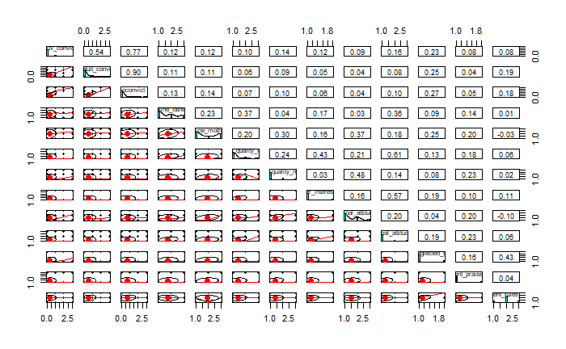

```r
adult_pt1.dat <- dplyr::select(adult_delinq.dat, njuv_convict, nadult_convict, nconvict,
                               discipline_father_8y, discipline_mother_8y, discipline_quality_father_8y, discipline_quality_mother_8y, father_interest_8y, maternal_attitude_8y, paternal_attitude_8y, neglected_8y, parent_praise_8y, parent_rules_8y)
adult_pt2.dat <- dplyr::select(adult_delinq.dat, njuv_convict, nadult_convict, nconvict,
                               permanent_sep_parent_8y, over1mo_sep_father_under5y, over1mo_sep_mother_under5y, over1mo_sep_parent_under5y, over1mo_sep_father_under10y, over1mo_sep_mother_under10y, over1mo_sep_parent_under10y, temp_sep_father_under5y, temp_sep_mother_under5y, temp_sep_parent_under5y, temp_sep_father_under10y, temp_sep_mother_under10y, temp_sep_parent_under10y)

adult_pt3.dat <- dplyr::select(adult_delinq.dat, njuv_convict, nadult_convict, nconvict,
                               parent_vigilance_8y, attitude_father_score_8y, attitude_mother_score_8y, pas_authoritarianism_parents_10y, maternal_attitude_10y, paternal_attitude_10y, pas_authoritarianism_father_10y, pas_authoritarianism_mother_10y, pas_underconcerned_mother_10y, supervision_parents_score_8y, parent_approval_12y, permanent_sep_parent_12y)
adult_pt4.dat <- dplyr::select(adult_delinq.dat, nadult_convict, nconvict,
                                 live_parents_home_16y, parents_alive_18y, live_parentsorfoster_home_16y, want_live_parents_home_18y, agreement_mother_18y, agreement_father_18y, harmony_parents_score_18y)
pairs.panels(adult_pt1.dat, method = "spearman")
```

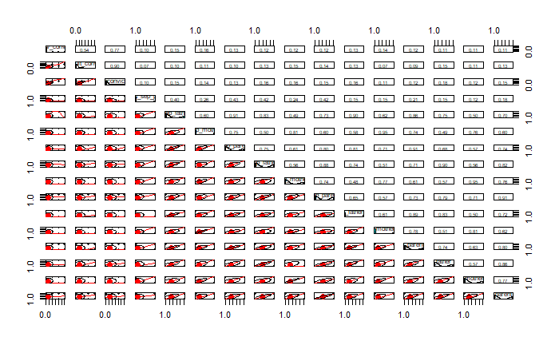

```r
pairs.panels(adult_pt2.dat, method = "spearman")
```

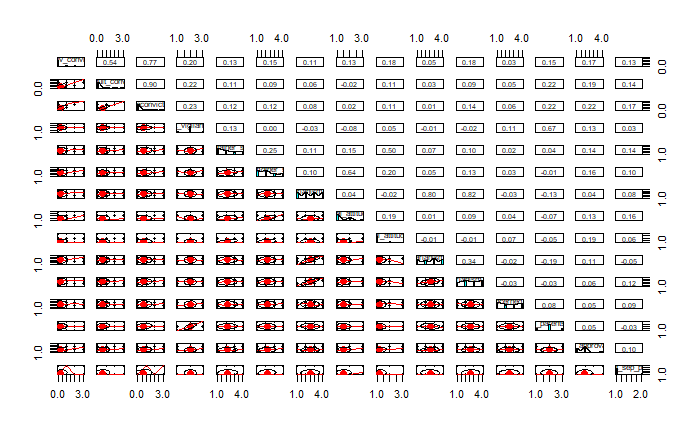

```r
pairs.panels(adult_pt3.dat, method = "spearman")
```

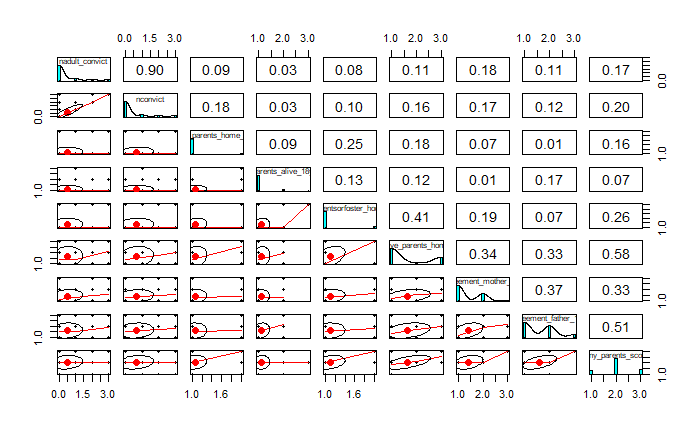

```r
pairs.panels(adult_pt4.dat, method = "spearman")
```

## This pattern of correlation is expected when looking at relational predictor variables. Often it is not one isolated aspect of the parent-child relationship that exclusively determines the outcome (e.g.: degree of criminality of the child), but an array of factors working together - each partially contributing to a relationship that either increses or decreases their liklihood of an outcome (e.g.: becoming a criminal)

Question 3: The sheer number of potential predictor variables is best handled with an approach that can identify the most important variables for a model. For this reason I will run a gradient boosted tree model

Juvenile model: First, we set the seed and create training and test sets (for the first model - predictors of juvenile delinquency). In the first attempt we see that there is a problem with the attributes of our potential predictor variables. We convert these all to factors and try again.

```r
juv_delinq.dat$njuv_convict <- as.factor(juv_delinq.dat$njuv_convict)
juv_delinq.dat$nadult_convict <- as.factor(juv_delinq.dat$nadult_convict)
juv_delinq.dat$nconvict <- as.factor(juv_delinq.dat$nconvict)
set.seed(1)
train_juv_delinq.dat <- sample_frac(juv_delinq.dat, 0.75)
test_juv_delinq.dat <- setdiff(juv_delinq.dat, train_juv_delinq.dat)
```

Next, we run the boosted model. In our first attempt we see that boosted tree models don’t allow for missing data. Thus we recode all NA values to 0, and re-run the training-test split and the model

```r
juv_delinq.dat0 <- juv_delinq.dat
juv_delinq.dat0 <- apply(juv_delinq.dat0, 2, function(x) {x[is.na(x)] <- 0; x})
juv_delinq.dat0 <- as.data.frame(juv_delinq.dat0)
set.seed(1)
train_juv_delinq.dat0 <- sample_frac(juv_delinq.dat0, 0.75)
test_juv_delinq.dat0 <- setdiff(juv_delinq.dat0, train_juv_delinq.dat0)


juv.boost0 = gbm(njuv_convict ~ . - nadult_convict - nconvict - PID, data = train_juv_delinq.dat0, n.trees = 5000, interaction.depth = 1, shrinkage = 0.01)
```

```
Distribution not specified, assuming multinomial ...
```

|  | var | rel.inf |
| --- | --- | --- |
| parent_approval_12y | parent_approval_12y | 8.74332492 |
| discipline_quality_mother_8y | discipline_quality_mother_8y | 7.35787504 |
| attitude_mother_score_8y | attitude_mother_score_8y | 6.89512576 |
| attitude_father_score_8y | attitude_father_score_8y | 6.48936921 |
| neglected_8y | neglected_8y | 5.95766585 |
| father_interest_8y | father_interest_8y | 5.62038252 |
| pas_underconcerned_mother_10y | pas_underconcerned_mother_10y | 5.36481983 |
| pas_authoritarianism_mother_10y | pas_authoritarianism_mother_10y | 5.11388959 |
| maternal_attitude_8y | maternal_attitude_8y | 4.16536431 |
| pas_authoritarianism_parents_10y | pas_authoritarianism_parents_10y | 4.12125898 |

[output cut: 25 more lines]

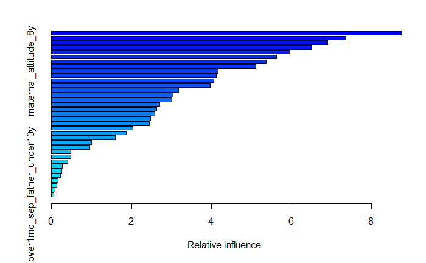

```r
summary(juv.boost0)
```

Next, we test to see which complexity parameters will be optimal for our model (the above model was run using trial complexity parameters)

```r
grid = expand.grid(.n.trees=seq(100,500, by=200), .interaction.depth=seq(1,4, by=1), .shrinkage=c(.001,.01,.1), .n.minobsinnode=10)
control = trainControl(method="CV", number=10)
gbm.juv_delinq0.train = train(njuv_convict~.- nadult_convict - nconvict - PID, data=train_juv_delinq.dat0, method="gbm",
 trControl=control, tuneGrid=grid)
View(gbm.juv_delinq0.train)
gbm.juv_delinq0.train
```

```
Stochastic Gradient Boosting

312 samples
 38 predictor
  4 classes: '0', '1', '2', '3'

No pre-processing
Resampling: Cross-Validated (10 fold)
Summary of sample sizes: 280, 280, 282, 280, 280, 281, ...
Resampling results across tuning parameters:

  shrinkage  interaction.depth  n.trees  Accuracy   Kappa
  0.001      1                  100      0.7918548  0.00000000
  0.001      1                  300      0.7918548  0.00000000
  0.001      1                  500      0.7918548  0.00000000
  0.001      2                  100      0.7918548  0.00000000
  0.001      2                  300      0.7918548  0.00000000
  0.001      2                  500      0.7918548  0.00000000
  0.001      3                  100      0.7918548  0.00000000
  0.001      3                  300      0.7918548  0.00000000
  0.001      3                  500      0.7918548  0.00000000
  0.001      4                  100      0.7918548  0.00000000
  0.001      4                  300      0.7918548  0.00000000
  0.001      4                  500      0.7918548  0.00000000
  0.010      1                  100      0.7918548  0.00000000
  0.010      1                  300      0.7950806  0.03514906
  0.010      1                  500      0.7853965  0.03169446
  0.010      2                  100      0.7918548  0.00000000
  0.010      2                  300      0.7886290  0.02658266
  0.010      2                  500      0.7789516  0.05350862
  0.010      3                  100      0.7918548  0.00000000
  0.010      3                  300      0.7854032  0.02225574
  0.010      3                  500      0.7791599  0.06411670
  0.010      4                  100      0.7918548  0.00000000
  0.010      4                  300      0.7789516  0.01694314
  0.010      4                  500      0.7761425  0.06684008
  0.100      1                  100      0.7664516  0.02972952
  0.100      1                  300      0.7631183  0.12258089
  0.100      1                  500      0.7334543  0.10727816
  0.100      2                  100      0.7662433  0.08574258
  0.100      2                  300      0.7493750  0.13605703
  0.100      2                  500      0.7270901  0.13174704
  0.100      3                  100      0.7660484  0.12821037
  0.100      3                  300      0.7209543  0.08532985
  0.100      3                  500      0.7141801  0.13423042
  0.100      4                  100      0.7727016  0.12918056
  0.100      4                  300      0.7334476  0.11353463
  0.100      4                  500      0.7177218  0.13278877

Tuning parameter 'n.minobsinnode' was held constant at a value of 10
Accuracy was used to select the optimal model using the largest value.
The final values used for the model were n.trees = 300, interaction.depth =
 1, shrinkage = 0.01 and n.minobsinnode = 10.
```

The results of train test: Tuning parameter ‘n.minobsinnode’ was held constant at a value of 10 Accuracy was used to select the optimal model using the largest value. The final values used for the model were n.trees = 300, interaction.depth = 1, shrinkage = 0.01 and n.minobsinnode = 10.

Next, we rerun the gradient boosted model with the optimal complexity parameters:

|  | var | rel.inf |
| --- | --- | --- |
| discipline_quality_mother_8y | discipline_quality_mother_8y | 15.0526247 |
| neglected_8y | neglected_8y | 14.1668813 |
| attitude_mother_score_8y | attitude_mother_score_8y | 12.5896958 |
| attitude_father_score_8y | attitude_father_score_8y | 7.0959258 |
| father_interest_8y | father_interest_8y | 6.9200520 |
| parent_approval_12y | parent_approval_12y | 6.2378622 |
| parent_vigilance_8y | parent_vigilance_8y | 4.9909021 |
| paternal_attitude_8y | paternal_attitude_8y | 4.7308937 |
| maternal_attitude_8y | maternal_attitude_8y | 3.8850269 |
| discipline_mother_8y | discipline_mother_8y | 3.8847432 |

[output cut: 25 more lines]

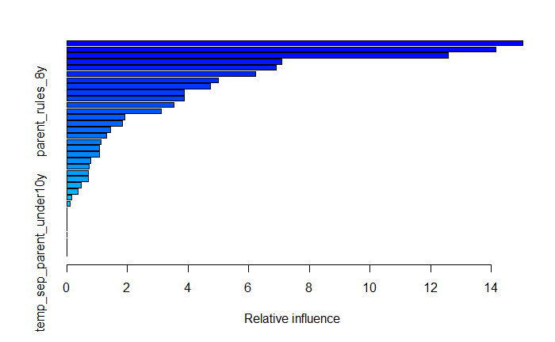

```r
juv.boost1 = gbm(njuv_convict ~. - nadult_convict - nconvict - PID, data = train_juv_delinq.dat0, distribution="multinomial",
 n.trees=300, interaction.depth=1, shrinkage=0.01)
summary(juv.boost1)
```

```r
juv.boost1.pred = predict(juv.boost1, newdata=test_juv_delinq.dat0, type="response",
 n.trees=300)
juv.boost1.test <- colnames(juv.boost1.pred)[base::apply(juv.boost1.pred, 1, base::which.max)]
confusionMatrix(as.factor(as.numeric(juv.boost1.test)), as.factor(test_juv_delinq.dat0$njuv_convict))
```

```
Levels are not in the same order for reference and data. Refactoring data to match.
```

```
Confusion Matrix and Statistics

          Reference
Prediction  0  1  2  3
         0 85 14  3  2
         1  0  0  0  0
         2  0  0  0  0
         3  0  0  0  0

Overall Statistics

               Accuracy : 0.8173
                 95% CI : (0.7295, 0.8863)
    No Information Rate : 0.8173
    P-Value [Acc > NIR] : 0.5609

                  Kappa : 0
 Mcnemar's Test P-Value : NA

Statistics by Class:

                     Class: 0 Class: 1 Class: 2 Class: 3
Sensitivity            1.0000   0.0000  0.00000  0.00000
Specificity            0.0000   1.0000  1.00000  1.00000
Pos Pred Value         0.8173      NaN      NaN      NaN
Neg Pred Value            NaN   0.8654  0.97115  0.98077
Prevalence             0.8173   0.1346  0.02885  0.01923
Detection Rate         0.8173   0.0000  0.00000  0.00000
Detection Prevalence   1.0000   0.0000  0.00000  0.00000
Balanced Accuracy      0.5000   0.5000  0.50000  0.50000
```

We see in the importance table above that the most important factors in determining juvenile delinquency are: quality of discipline by mother (recorded at ages 8-9), if the boy was neglected (recoreded: ages 8-9), the composite mother attitude score (consisting of maternal attitude, discipline quality of mother, and discipline of mother; recorded: ages 8-9), the composite father attitude score (paternal variant of mother attitude score; recorded ages 8-9), the interest of the father in the boy (recorded: ages 8-9), and parent approval of the boy (recorded: ages 12-13). Thus the discipline type and quality provided by each parent, along with the parents’ interest in, approval of and attitude towards the child during their earliest years (under 10years old) is most important in determining juvenile delinquency. If the child is neglected, their parents are likely to score poorly on all the above measures. Thus early neglect functions here as an indicator of the other important variables - thus neglect (present) is very important in predicting juvenile criminality.

## Next we need to assess the value of the model. We see that the model is 82% accurate. This looks fantastic until we look at the confusion matrix - the model predicts that no-one is a criminal, and it gets this right 82% of the time. Sensitivity and specificity values highlight this problem - this model has a sensitivity of 1.00 for identifying non-criminals, but a sensitivity of 0.00 for each of the 3 classes of juvenile criminals (1, 2-3, or 4 or more convictions, respectively)

Adult model We abandon the gradient boosted juvenile model and attempt a gradient boosted model for adult criminality In our first gbm we see that boosted tree models don’t allow for missing data, thus we recode all NA values to 0. Then we set the seed and create training and test sets (for the second model - predictors of adult delinquency).

```r
adult_delinq.dat$njuv_convict <- as.factor(adult_delinq.dat$njuv_convict)
adult_delinq.dat$nadult_convict <- as.factor(adult_delinq.dat$nadult_convict)
adult_delinq.dat$nconvict <- as.factor(adult_delinq.dat$nconvict)
adult_delinq.dat0 <- adult_delinq.dat
adult_delinq.dat0 <- apply(adult_delinq.dat0, 2, function(x) {x[is.na(x)] <- 0; x})
adult_delinq.dat0 <- as.data.frame(adult_delinq.dat0)
set.seed(1)
train_adult_delinq.dat0 <- sample_frac(adult_delinq.dat0, 0.75)
test_adult_delinq.dat0 <- setdiff(adult_delinq.dat0, train_adult_delinq.dat0)
```

Next, we test to see which complexity parameters will be optimal for our model

```r
grid = expand.grid(.n.trees=seq(100,500, by=200), .interaction.depth=seq(1,4, by=1), .shrinkage=c(.001,.01,.1), .n.minobsinnode=10)

control = trainControl(method="CV", number=10)

gbm.adult_delinq0.train = train(nadult_convict~.- njuv_convict - nconvict - PID, data=train_adult_delinq.dat0, method="gbm",
 trControl=control, tuneGrid=grid)

#gbm.juv_delinq0.train
```

```r
gbm.adult_delinq0.train
```

```
Stochastic Gradient Boosting

312 samples
 45 predictor
  4 classes: '0', '1', '2', '3'

No pre-processing
Resampling: Cross-Validated (10 fold)
Summary of sample sizes: 280, 281, 281, 281, 280, 282, ...
Resampling results across tuning parameters:

  shrinkage  interaction.depth  n.trees  Accuracy   Kappa
  0.001      1                  100      0.7341196   0.000000000
  0.001      1                  300      0.7341196   0.000000000
  0.001      1                  500      0.7341196   0.000000000
  0.001      2                  100      0.7341196   0.000000000
  0.001      2                  300      0.7341196   0.000000000
  0.001      2                  500      0.7341196   0.000000000
  0.001      3                  100      0.7341196   0.000000000
  0.001      3                  300      0.7341196   0.000000000
  0.001      3                  500      0.7341196   0.000000000
  0.001      4                  100      0.7341196   0.000000000
  0.001      4                  300      0.7341196   0.000000000
  0.001      4                  500      0.7341196   0.000000000
  0.010      1                  100      0.7341196   0.000000000
  0.010      1                  300      0.7341196   0.015226377
  0.010      1                  500      0.7244355   0.010101776
  0.010      2                  100      0.7341196   0.000000000
  0.010      2                  300      0.7275605   0.027253879
  0.010      2                  500      0.7212097   0.036471211
  0.010      3                  100      0.7341196   0.000000000
  0.010      3                  300      0.7212097   0.004772026
  0.010      3                  500      0.7052823   0.018083252
  0.010      4                  100      0.7341196   0.000000000
  0.010      4                  300      0.7212097   0.017689602
  0.010      4                  500      0.6959073   0.013298624
  0.100      1                  100      0.6924731   0.040238303
  0.100      1                  300      0.6573925   0.043342263
  0.100      1                  500      0.6252352  -0.002956078
  0.100      2                  100      0.6765524   0.008545494
  0.100      2                  300      0.6415726   0.015882764
  0.100      2                  500      0.6382460   0.026763354
  0.100      3                  100      0.6764449   0.049538362
  0.100      3                  300      0.6607258   0.052139516
  0.100      3                  500      0.6605242   0.079507107
  0.100      4                  100      0.6828965   0.058589902
  0.100      4                  300      0.6606250   0.074893478
  0.100      4                  500      0.6412702   0.045578711

Tuning parameter 'n.minobsinnode' was held constant at a value of 10
Accuracy was used to select the optimal model using the largest value.
The final values used for the model were n.trees = 100, interaction.depth =
 1, shrinkage = 0.001 and n.minobsinnode = 10.
```

The results of train test: Tuning parameter ‘n.minobsinnode’ was held constant at a value of 10 Accuracy was used to select the optimal model using the largest value. The final values used for the model were n.trees = 100, interaction.depth = 1, shrinkage = 0.001 and n.minobsinnode = 10.

Next, we rerun the gradient boosted model with the optimal complexity parameters:

|  | var | rel.inf |
| --- | --- | --- |
| neglected_8y | neglected_8y | 13.2464962 |
| discipline_mother_8y | discipline_mother_8y | 9.9477377 |
| parent_rules_8y | parent_rules_8y | 8.0940155 |
| maternal_attitude_10y | maternal_attitude_10y | 7.6752612 |
| attitude_mother_score_8y | attitude_mother_score_8y | 7.6611527 |
| paternal_attitude_10y | paternal_attitude_10y | 7.5141759 |
| parent_approval_12y | parent_approval_12y | 5.7030158 |
| parent_vigilance_8y | parent_vigilance_8y | 5.4508429 |
| temp_sep_father_under5y | temp_sep_father_under5y | 5.3788661 |
| discipline_father_8y | discipline_father_8y | 4.8393670 |

[output cut: 32 more lines]

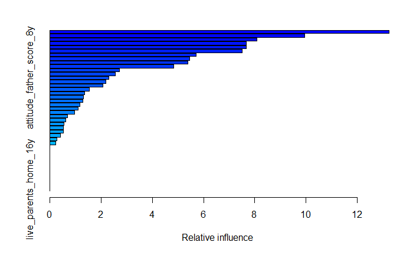

```r
adult.boost1 = gbm(nadult_convict ~. - njuv_convict - nconvict - PID, data = train_adult_delinq.dat0, distribution="multinomial",
 n.trees=100, interaction.depth=1, shrinkage=0.001)
summary(adult.boost1)
```

```r
adult.boost1.pred = predict(adult.boost1, newdata=test_adult_delinq.dat0, type="response",
 n.trees=100)
adult.boost1.test <- colnames(adult.boost1.pred)[base::apply(adult.boost1.pred, 1, base::which.max)]
confusionMatrix(as.factor(as.numeric(adult.boost1.test)), as.factor(test_adult_delinq.dat0$nadult_convict))
```

```
Levels are not in the same order for reference and data. Refactoring data to match.
```

```
Confusion Matrix and Statistics

          Reference
Prediction  0  1  2  3
         0 80  9  9  6
         1  0  0  0  0
         2  0  0  0  0
         3  0  0  0  0

Overall Statistics

               Accuracy : 0.7692
                 95% CI : (0.6764, 0.8462)
    No Information Rate : 0.7692
    P-Value [Acc > NIR] : 0.5545

                  Kappa : 0
 Mcnemar's Test P-Value : NA

Statistics by Class:

                     Class: 0 Class: 1 Class: 2 Class: 3
Sensitivity            1.0000  0.00000  0.00000  0.00000
Specificity            0.0000  1.00000  1.00000  1.00000
Pos Pred Value         0.7692      NaN      NaN      NaN
Neg Pred Value            NaN  0.91346  0.91346  0.94231
Prevalence             0.7692  0.08654  0.08654  0.05769
Detection Rate         0.7692  0.00000  0.00000  0.00000
Detection Prevalence   1.0000  0.00000  0.00000  0.00000
Balanced Accuracy      0.5000  0.50000  0.50000  0.50000
```

## We skip ahead to the confusion matrix and see that we have the same problem here - the model predicts that everyone will not be a criminal.

We now consider alternative models 1. LDA 2. Random Forests

1. We run an LDA to predict juvenile delinquency

```r
lda.juv_delinq1 <- lda(njuv_convict ~. - nadult_convict - nconvict - PID, data = train_juv_delinq.dat0)
```

```
variables are collinear
```

We see here that we have a problem of colliearity among the variables (this makes sense, as some variables are composite scores/subsets of other variables).

2. We run a random forests model to predict juvenile delinquency

```r
rf.juv_delinq1 <- randomForest(njuv_convict ~. - nadult_convict - nconvict - PID, data = train_juv_delinq.dat0)
print(rf.juv_delinq1)
```

```
Call:
 randomForest(formula = njuv_convict ~ . - nadult_convict - nconvict -      PID, data = train_juv_delinq.dat0)
               Type of random forest: classification
                     Number of trees: 500
No. of variables tried at each split: 5

        OOB estimate of  error rate: 20.51%
Confusion matrix:
    0 1 2 3 class.error
0 243 2 1 1  0.01619433
1  30 2 1 0  0.93939394
2  15 1 3 0  0.84210526
3  13 0 0 0  1.00000000
```

THe estimated error rate is 20.51% - this doesn’t look bad, but we can improve and analyse the model further.

Next, we determine which number of trees will lead to the lowest error rate

```r
which.min(rf.juv_delinq1$err.rate[,1])
```

```
[1] 262
```

We see that the lowest error rate is with 262 trees. We use the new tree model with ntrees = 262 to predict the test data set. After that we create a confusion matrix to check model accuracy

```r
rf.juv_delinq2 = randomForest(njuv_convict ~. - nadult_convict - nconvict - PID, data = train_juv_delinq.dat0, ntree=262)
print(rf.juv_delinq2)
```

```
Call:
 randomForest(formula = njuv_convict ~ . - nadult_convict - nconvict -      PID, data = train_juv_delinq.dat0, ntree = 262)
               Type of random forest: classification
                     Number of trees: 262
No. of variables tried at each split: 5

        OOB estimate of  error rate: 20.51%
Confusion matrix:
    0 1 2 3 class.error
0 244 1 1 1  0.01214575
1  30 2 1 0  0.93939394
2  16 1 2 0  0.89473684
3  13 0 0 0  1.00000000
```

```r
rf.juv_delinq2.pred = predict(rf.juv_delinq2, newdata=test_juv_delinq.dat0, type="response")
confusionMatrix(data = rf.juv_delinq2.pred, reference = test_juv_delinq.dat0$njuv_convict)
```

```
Confusion Matrix and Statistics

          Reference
Prediction  0  1  2  3
         0 83 14  3  2
         1  2  0  0  0
         2  0  0  0  0
         3  0  0  0  0

Overall Statistics

               Accuracy : 0.7981
                 95% CI : (0.7081, 0.8704)
    No Information Rate : 0.8173
    P-Value [Acc > NIR] : 0.7423

                  Kappa : -0.0312
 Mcnemar's Test P-Value : NA

Statistics by Class:

                     Class: 0 Class: 1 Class: 2 Class: 3
Sensitivity            0.9765  0.00000  0.00000  0.00000
Specificity            0.0000  0.97778  1.00000  1.00000
Pos Pred Value         0.8137  0.00000      NaN      NaN
Neg Pred Value         0.0000  0.86275  0.97115  0.98077
Prevalence             0.8173  0.13462  0.02885  0.01923
Detection Rate         0.7981  0.00000  0.00000  0.00000
Detection Prevalence   0.9808  0.01923  0.00000  0.00000
Balanced Accuracy      0.4882  0.48889  0.50000  0.50000
```

From these attempts we conclude that criminality (and degree of criminality) is not determined by parent-child relational variables (limited to the variables explored above)

```r
juv_delinq_binary.dat0 <- juv_delinq.dat0
juv_delinq_binary.dat0$njuv_convict <- recode(juv_delinq_binary.dat0$njuv_convict, "1=0; 2:4=1")
juv_delinq_binary.dat0$nadult_convict <- recode(juv_delinq_binary.dat0$nadult_convict, "1=0; 2:4=1")
juv_delinq_binary.dat0$nconvict <- recode(juv_delinq_binary.dat0$nconvict, "1=0; 2:4=1")
```

Check the outcome variable

```r
table(juv_delinq_binary.dat0$njuv_convict)
```

[output not shown]

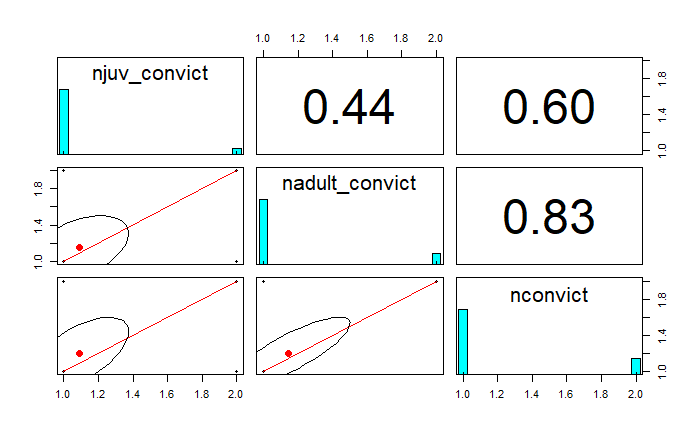

```r
juv_binary_outcome <- dplyr::select(juv_delinq_binary.dat0, njuv_convict, nadult_convict, nconvict)
juv_binary_outcome <- as.data.frame(juv_binary_outcome)
pairs.panels(juv_binary_outcome, method = "spearman")
```

Next we set a seed, create test and training sets, and run a logistic regression to determine which parent-child relational variables are predictive of criminality (in a binary distinction)

```r
set.seed(1)
train_juv_delinq_binary.dat0 <- sample_frac(juv_delinq_binary.dat0, 0.75)
test_juv_delinq_binary.dat0 <- setdiff(juv_delinq_binary.dat0, train_juv_delinq_binary.dat0)
glm.juv_binary <- glm(njuv_convict ~. - nadult_convict - nconvict - PID, family = "binomial", data = train_juv_delinq_binary.dat0)
```

```
glm.fit: algorithm did not convergeglm.fit: fitted probabilities numerically 0 or 1 occurred
```

```r
summary(glm.juv_binary)
```

```
Call:
glm(formula = njuv_convict ~ . - nadult_convict - nconvict -
    PID, family = "binomial", data = train_juv_delinq_binary.dat0)

Deviance Residuals:
   Min      1Q  Median      3Q     Max
 -8.49    0.00    0.00    0.00    8.49

Coefficients: (14 not defined because of singularities)
                                     Estimate Std. Error    z value Pr(>|z|)
(Intercept)                        -6.267e+15  2.778e+07 -225573041   <2e-16 ***
discipline_father_8y 2              1.625e+15  2.982e+07   54508468   <2e-16 ***
discipline_father_8y 3              2.454e+15  4.586e+07   53518625   <2e-16 ***
discipline_father_8y0               1.672e+15  8.695e+07   19224395   <2e-16 ***
discipline_mother_8y 2             -4.432e+13  2.557e+07   -1733451   <2e-16 ***
discipline_mother_8y 3              1.236e+15  2.821e+07   43820062   <2e-16 ***
discipline_mother_8y0              -5.877e+15  8.798e+07  -66796718   <2e-16 ***
discipline_quality_father_8y 2      3.851e+14  2.743e+07   14038930   <2e-16 ***
discipline_quality_father_8y 3      3.647e+15  3.528e+07  103364019   <2e-16 ***
discipline_quality_father_8y0      -2.561e+15  1.061e+08  -24146688   <2e-16 ***
discipline_quality_mother_8y 2      2.300e+15  1.912e+07  120296388   <2e-16 ***
discipline_quality_mother_8y 3      2.147e+15  3.129e+07   68618046   <2e-16 ***
discipline_quality_mother_8y0       4.697e+15  8.780e+07   53498412   <2e-16 ***
father_interest_8y 2               -8.143e+14  1.862e+07  -43735941   <2e-16 ***
father_interest_8y0                 1.981e+15  3.327e+07   59538473   <2e-16 ***
maternal_attitude_8y 2             -3.231e+14  2.408e+07  -13418626   <2e-16 ***
maternal_attitude_8y 3              3.998e+14  3.195e+07   12513566   <2e-16 ***
maternal_attitude_8y0              -2.360e+15  7.804e+07  -30235494   <2e-16 ***
paternal_attitude_8y 2              2.964e+15  3.101e+07   95554843   <2e-16 ***
paternal_attitude_8y 3              1.603e+15  3.506e+07   45709362   <2e-16 ***
paternal_attitude_8y0              -2.254e+15  3.694e+07  -61034695   <2e-16 ***
neglected_8y 2                      1.148e+15  1.764e+07   65067114   <2e-16 ***
neglected_8y0                       6.896e+14  3.130e+07   22032258   <2e-16 ***
parent_praise_8y 2                  7.480e+14  1.619e+07   46190015   <2e-16 ***
parent_praise_8y0                  -1.085e+15  2.740e+07  -39591652   <2e-16 ***
parent_rules_8y 2                  -8.646e+13  2.571e+07   -3363131   <2e-16 ***
parent_rules_8y 3                  -1.133e+15  4.164e+07  -27218582   <2e-16 ***
parent_rules_8y0                   -2.924e+14  4.385e+07   -6667101   <2e-16 ***
permanent_sep_parent_8y 2          -3.506e+14  2.854e+07  -12287727   <2e-16 ***
permanent_sep_parent_8y0           -5.775e+15  4.657e+07 -124026452   <2e-16 ***
```

[output cut: 61 more lines]

```
parent_approval_12y 3               1.269e+15  1.948e+07   65112172   <2e-16 ***
parent_approval_12y 4               7.203e+14  1.677e+07   42940094   <2e-16 ***
parent_approval_12y0                1.435e+15  2.244e+07   63955996   <2e-16 ***
permanent_sep_parent_12y 2          1.366e+14  1.838e+07    7432599   <2e-16 ***
permanent_sep_parent_12y0                  NA         NA         NA       NA
---
Signif. codes:  0 ‘***’ 0.001 ‘**’ 0.01 ‘*’ 0.05 ‘.’ 0.1 ‘ ’ 1

(Dispersion parameter for binomial family taken to be 1)

    Null deviance:  206.34  on 311  degrees of freedom
Residual deviance: 1009.22  on 230  degrees of freedom
AIC: 1173.2

Number of Fisher Scoring iterations: 25
```

The error message suggests that the predictor variables are not linear-independent, or one of the PVs correlates perfectly with the DV.

We know from the initial pairs panel that none of the predictor variables correlate completely with the outcome variable. And based on the diagnosis of multicollinearity from the attempted LDA, we conclude that a logistic regression is prohibited due to the degree of collinearity.

Thus we conclude that we cannot determine criminality from parent-child relational variables